# Bayesian Models and Regression

Massimo Petretich

March 2020

# 1 Introduction

## 1.1 Bayesian vs Frequentist approach

A good introduction to the topic is presented by Annette Dobson in her book ‘An introduction to generalized linear model’. Although the book itself does not focus primarily on Bayesian models, it provides all the foundations required to build a Bayesian thinking.  
When it comes to estimating the parameter(s) of a population, frequentist and Bayesian approaches start from completely different assumptions.  
In the frequentist approach the parameter is considered fixed whereas the random process used for its determination (observations) is variable (repeated ‘n’ times). The estimate of the ‘true’ parameter is achieved for n –> infinity. The estimate of the parameter ($\mathrm{P}(X \mid\theta)$) is obtained by finding the maximum point in the likelihood function.  
In the Bayesian approach instead, the observations are considered fixed and the parameter is the variable entity. The parameter in bayesian statistics is considered just like any random variable, for example like 1 dice if we are throwing 2 dices, and, as a consequence its distribution can be modeled as a probability density function (or a probability mass function if we deal with count or categorical samples). In bayesian statistics the probability density function of the parameter ($\mathrm{P}(\theta)$) is referred to as ‘prior’ and represents our prior belief regarding the distribution of the parameter. The posterior distribution ($\mathrm{P}(\theta\mid X)$) is nothing but the product of the likelihood function and the prior distribution as shown in equation 1. The denominator in equation 1 is just the integral of this product over the whole parameter space. Its presence in the equation ensures that the posterior probability density function integrates to 1. This terms is often omitted (in this tutorial it is omitted) for computational reasons since by doing so the estimates of the parameter’s value does not change.  
Equation 1:  
$\mathrm{P}(\theta\mid X) = \frac {\mathrm{P}(X \mid\theta)\mathrm{P}(\theta)} {\sum \mathrm{P}(X \mid\theta)\mathrm{P}(\theta)}$

## 1.2 Markov-Chain Monte-Carlo

While the maximum likelihood algorithms aim to find the maximum point of the likelihood in the most efficient way (with less computations), in the Bayesian approach, the aim is to ‘map’ (or in more statistical terms, “sample”) the posterior probability density function as finely as possible in order to estimate not only the maximum value, but also, the confidence intervals around this value. This may not be necessary for very simple models (would be just an inefficient way of determining the parameter’s value). This approach gains power in all those situation where the likelihood functions may be too complex to be determined algebrically, may be unknown, or have multi-modal nature (in this latter case the maximum likelihood methods would just find 1 maximum value, for more details, consult the Appendix). There are different algorithms available to map the parameter space of the posterior probability density function. Here we use the classic Markov-Chain Monte-Carlo (MCMC) Metropolis-Hastings algorithm. Despite the fact that several physicists contributed to the development of the Monte-Carlo Markov-Chain method, it was Stanislaw Ulam who implemented the modern version of the method in the ’40s. The name Monte-Carlo is alleged to originate from the place where a relative from Stan Ulam used to gamble. Despite the fact that the explanation of the Metropolis-Hastings algorithm goes beyond the scope of this tutorial, the example below introduces its logic with a simple practical application.

# 2 The Metropolis-Hastings algorithm

## 2.1 Normal distribution example

In this example we use the Metropolis-Hastings algorithm to sample the probability density function of a normal distribution with $\mu = 10$ and $\sigma = 2$.  
Equation2: Probability density function of the normal distribution  
$\mathrm{P}(X \mid \mu, \sigma^{2}) = (2 \pi \sigma^{2})^{-1/2} e^{-0.5(\frac{X-\mu}{\sigma})}$  
Importantly, here we are not yet applying any bayesian statistical concept.  
Also, this algorithm is not thought to be efficient, for example on point (2) to calculate the improvement we compute the probabilites for the current and the previous value of ‘x’. Clearly, it does not make sense to repeat previous computations from the previous iterations. The ‘good’ way of doing this would be to store the probabilities of every iterations on another vector (e’g’ ‘p’) and access them every iteration as p[i-1]. Here in order to keep the code as simple as possible we reduced the number of objects involved, to keep the code more readable (to the detriment of performance).

1: MONTE-CARLO part of the algorithm (random sampling). Generating a new random variable  
2: MARKOV-CHAIN part of the algorithm, the improvement is calculated on the basis of the previous value (compares the probabilities of the new random variable with the one of the previous iteration)  
3: If the new random variable gives an improvement (> 1) this line returns 1  
4: This step ensures that the algorithm does not get stuck on the point of maxima (like it would in a standard maximum likelihood estimate) but keeps refining the mapping around the point of maxima

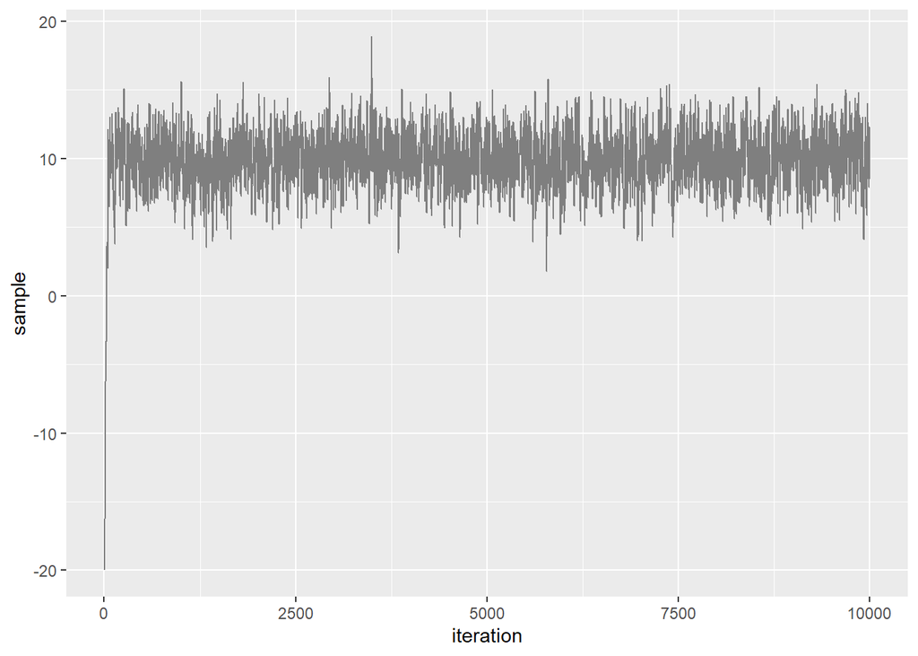

```r
library(tidyverse)
library(ggplot2)

model_pdf <- function(x, mu, sigma) exp(-0.5 * ((x - mu) / sigma)^2) / (sigma*sqrt(2*pi)) # probability density function
proposed <- function(x, sd) rnorm(n = 1, mean = x, sd = sd) # random variable generation

iterations = 1e4 # number of iterations
x <- -20 # starting value of the chain
sigma = 2
mu = 10
stored <- rep(NA, iterations)
improvement <- rep(NA, iterations)

for (i in 1:iterations) {
  x_i <- proposed(x, sigma) # 1
  improvement[i] <- model_pdf(x_i, mu, sigma) / model_pdf(x, mu, sigma) # 2
  ratio <- min(1, improvement[i]) # 3
  accept <- runif(1) < ratio # 4
  stored[i] <- ifelse(accept, x_i, x)
  x <- stored[i]
}

results_combined = data.frame(sample = stored, improvement = improvement, iteration = 1:iterations)

ggplot(data = results_combined, aes(x = iteration, y = sample)) + geom_line(colour = 'grey50')
```

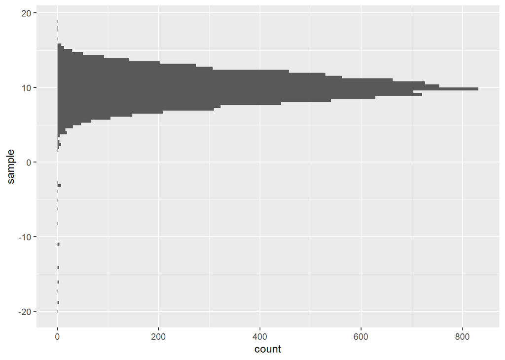

```r
ggplot(data = results_combined, aes(y=sample)) + geom_histogram(bins = 100)
```

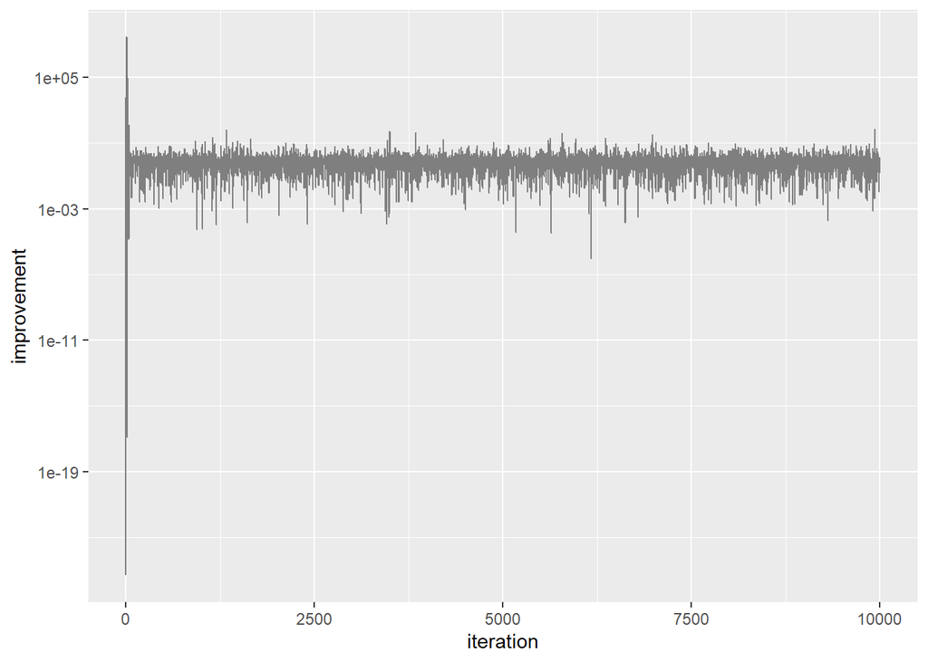

```r
ggplot(data = results_combined, aes(x = iteration, y = improvement)) + geom_line(colour = 'grey50') + scale_y_log10()
```

# 3 Bayesian model fitting

## 3.1 Normal distribution (linear model with just the intercept as parameter)

1. Why did we specify the probability density function for the normal distribution instead of using the built-in function in R? After all ‘model_pdf(12, 10, 2)’ gives the same result as ‘stats::dnorm(12, 10, 2)’.

This is done for the same reason as we define our own Metropolis-Hastings algorithm instead of just using any of the available implementations found in different packages. The purpose of the tutorial is to break apart the model fitting as much as possible.

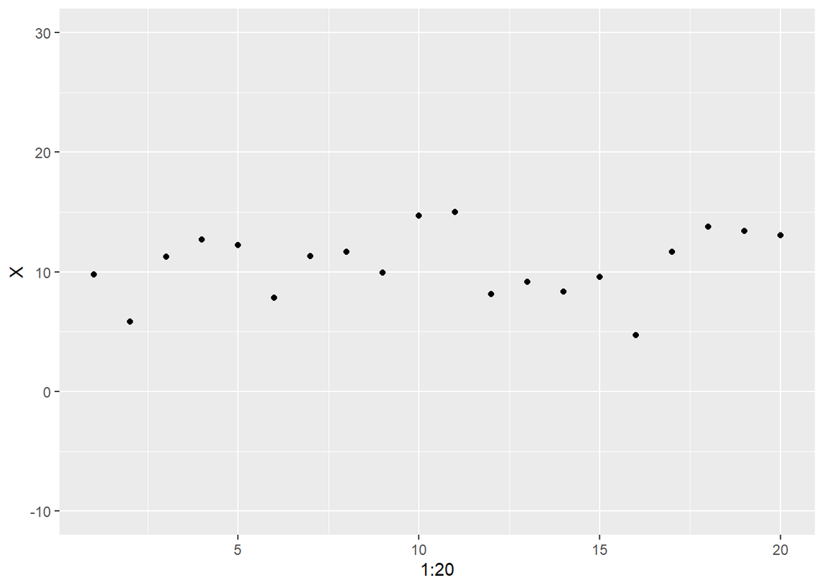

```r
library(tidyverse)
library(ggplot2)

X <- rnorm(n = 20, mean = 10, sd = 4) # Our sample from the population (normal population with mean 10 and standard deviation 4)

qplot(x = 1:20, y = X) + expand_limits(y = c(-10, 30))
```

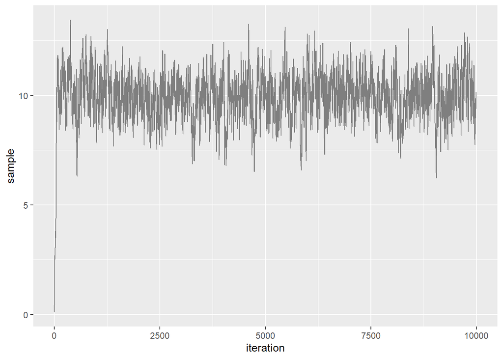

```r
model_pdf <-  function(obs, mu, sigma) exp(-0.5*((obs-mu)/sigma)^2) / (sqrt(sigma^2*2*pi)) # 1

posterior_pdf <- function(x, mu, sigma, mu_prior, sigma_prior) model_pdf(x, mu, sigma) * model_pdf(mu, mu_prior, sigma_prior) # likelihood * prior

proposed <- function(mu, sd) rnorm(n = 1, mean = mu, sd = sd)

iterations = 1e4
mu <- 0 # start of the chain (slope)
sigma_proposed = 0.5

sigma <- 5
mu_prior <- 7
sigma_prior <- 10 # standard deviation of the normal model used for the likelihood probability density function. Here we consider it as a nuisance parameter, namely, we do not aim to estimate it but we provide it to the model
stored <- rep(NA, iterations)


for (i in 1:iterations) {
  mu_prime <- proposed(mu, sigma_proposed)

  i_posterior_p <- posterior_pdf(X, mu_prime, sigma, mu_prior, sigma_prior)
  i_posterior_p <- Reduce(`*`, i_posterior_p) # 1

  previous_posterior_p <- posterior_pdf(X, mu, sigma, mu_prior, sigma_prior)
  previous_posterior_p <- Reduce(`*`, previous_posterior_p) #1

  improvement <- i_posterior_p / previous_posterior_p

  ratio <- min(1, improvement)
  accept <- runif(1) < ratio
  stored[i] <- ifelse(accept, mu_prime, mu)
  mu <- stored[i]
}

results_combined = data.frame(sample = stored, improvement = improvement, iteration = 1:iterations)

ggplot(data = results_combined, aes(x = iteration, y = sample)) + geom_line(colour = 'grey50')
```

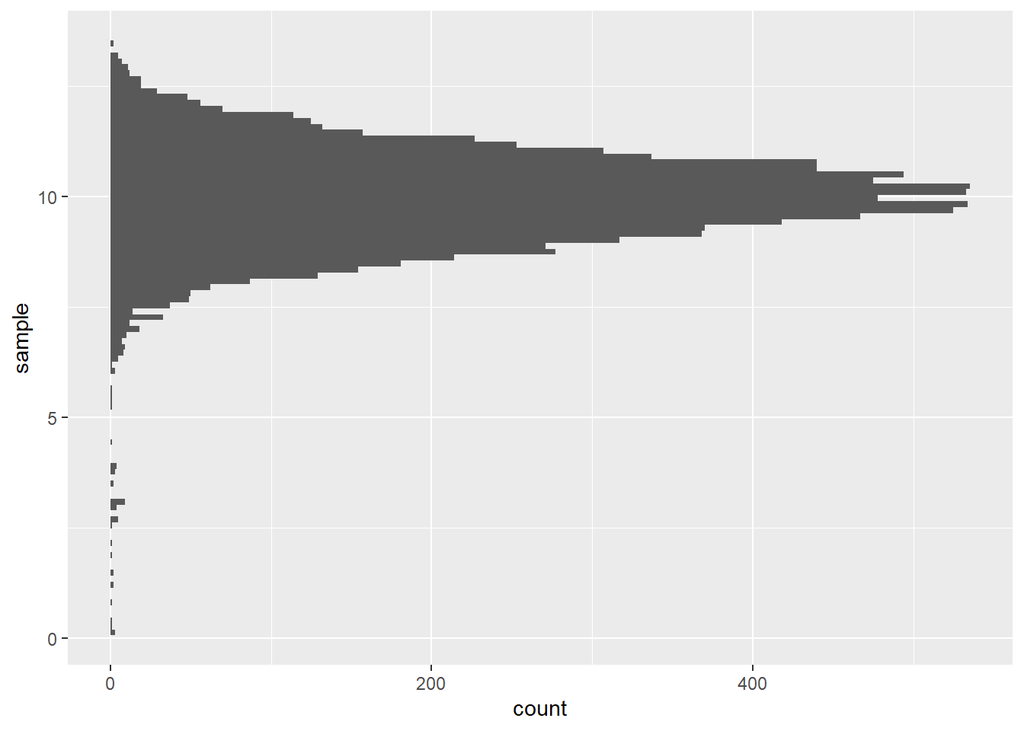

```r
ggplot(data = results_combined, aes(y=sample)) + geom_histogram(bins = 100)
```

## 3.2 Linear model (parameter: slope)

The previous example was the simplest linear model, the one with only the intercept as parameter.  
In the next example we will implement the next step: estimating the slope (‘b’) of a linear model (for now) without intercept.  
Our prior distribution (regarding the estimate of the coefficient ‘b’) is 2.5 with a standard deviation of 0.5. To be noted in the results that with this ‘strong’ (small sigma) prior, the estimate of the posterior probability density function is pulled towards 2.5 (mean of the prior) when in reality it is 3 (in the dataset used). Excersise: try to weaken the prior by increasing sigma and see if the estimate of the coefficient ‘b’ approaches 3.

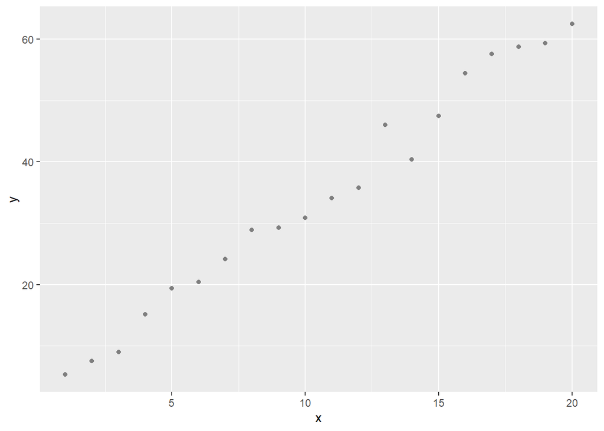

```r
library(tidyverse)
library(ggplot2)

population_b <- 3 # slope
dataset <- data.frame(x = 1:20, y = sapply(1:20, function(x) population_b * (x + rnorm(n = 1, mean = 1, sd = 1))))
ggplot(data = dataset, aes(x = x, y = y)) + geom_point(colour = 'grey50')
```

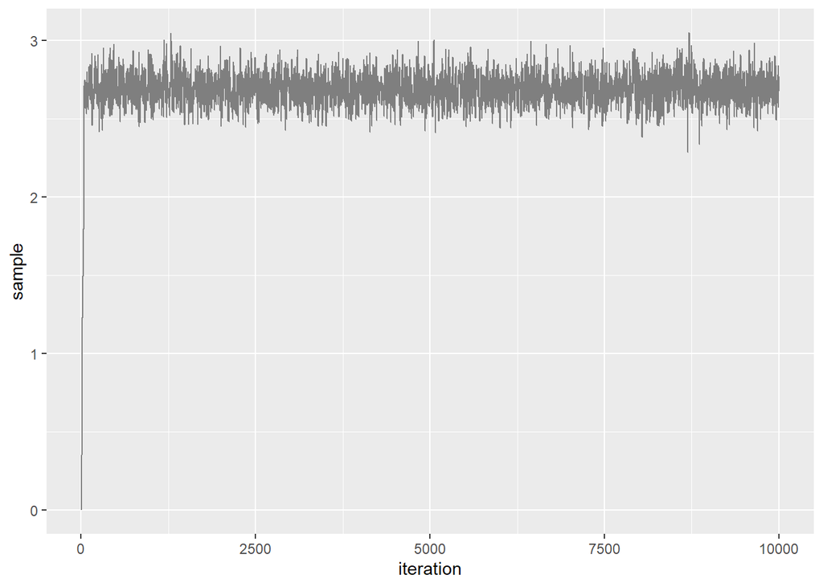

```r
model_pdf <-  function(obs, mu, sigma) exp(-0.5*((obs-mu)/sigma)^2)/(sqrt(sigma^2*2*pi))

posterior_pdf <- function(y, x, b, sigma, b_prior, sigma_prior) model_pdf(y, b*x, sigma) * model_pdf(b, b_prior, sigma_prior) # likelihood * prior

proposed <- function(b, sd) rnorm(n = 1, mean = b, sd = sd)

iterations = 1e4
b <- 0 # start of the chain (slope)
sigma_proposed = 0.2
sigma <- 10 # standard deviation of the normal model used for the likelihood probability density function. Here we consider it as a nuisance parameter, namely, we do not aim to estimate it but we provide it to the model
b_prior <- 2.5 # prior belief of the slope
sigma_prior <- 0.5 # standard deviation of the coefficient, not y!
stored <- rep(NA, iterations)


for (i in 1:iterations) {
  b_prime <- proposed(b, sigma_proposed)

  i_posterior_p <- posterior_pdf(dataset$y, dataset$x, b_prime, sigma, b_prior, sigma_prior)
  i_posterior_p <- Reduce(`*`, i_posterior_p)

  previous_posterior_p <- posterior_pdf(dataset$y, dataset$x, b, sigma, b_prior, sigma_prior)
  previous_posterior_p <- Reduce(`*`, previous_posterior_p)

  improvement <- i_posterior_p / previous_posterior_p

  ratio <- min(1, improvement)
  accept <- runif(1) < ratio
  stored[i] <- ifelse(accept, b_prime, b)
  b <- stored[i]
}

results_combined = data.frame(sample = stored, improvement = improvement, iteration = 1:iterations)

ggplot(data = results_combined, aes(x = iteration, y = sample)) + geom_line(colour = 'grey50')
```

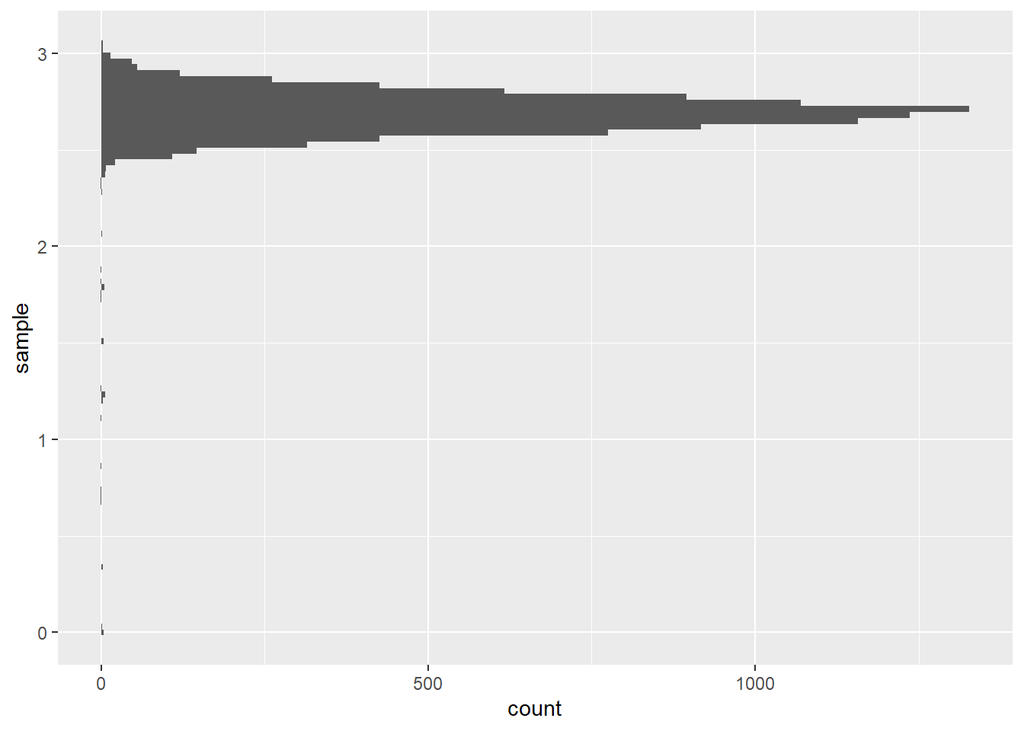

```r
ggplot(data = results_combined, aes(y=sample)) + geom_histogram(bins = 100)
```

Let’s check how the model fits the data.

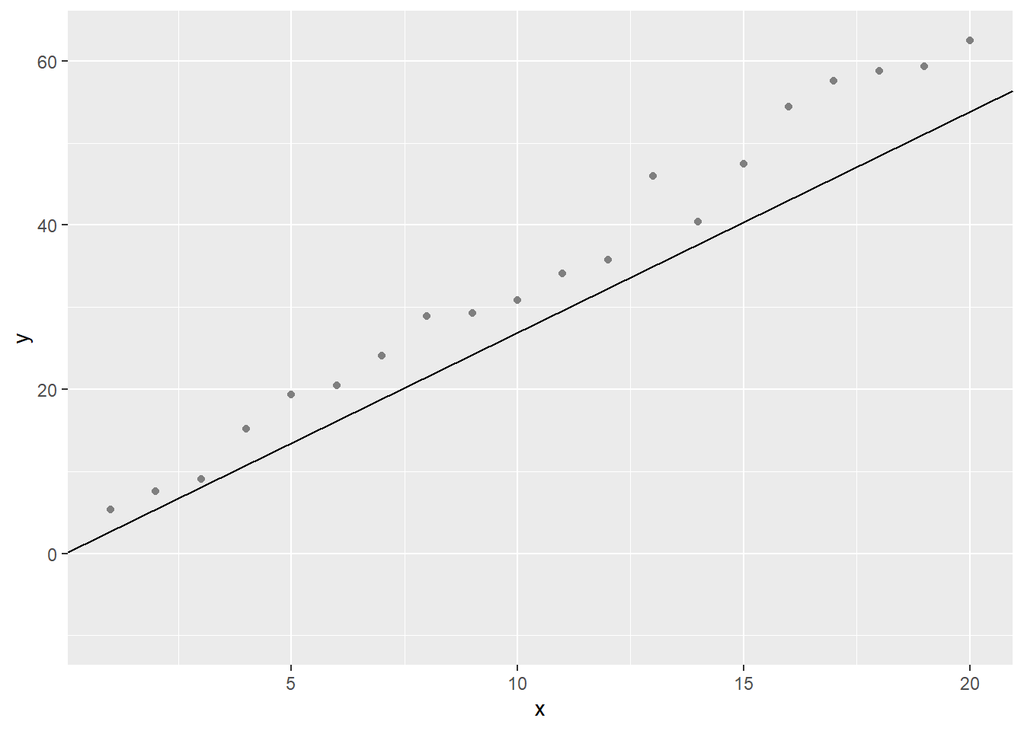

```r
b <- median(results_combined$sample)
ggplot(data = dataset, aes(x = x, y = y)) + geom_point(colour = 'grey50') + geom_abline(intercept = 0, slope = b) + expand_limits(y = -10)
```

It is clear from how the model fits the data that this is not a good model.This was done on purpose to underly one important concept in Bayesian statistics: the prior can influence the posterior as much as the likelihood function does (or even more if we feed the model a very strong prior). In this case we chose $\mu = 2.5$ and $\sigma = 0.5$.  
Usually, there must be a reason justifying a strong prior. One example of this is provided in the Deseq2 package. Here the shrinkage estimator works exactly in the way described above, the log 2 fold changes for low read-counts are schrunken towards 0 because in that region of the transcriptome the likelihood is weakened by a great deal of experimental noise and therefore the prior has higher influence. For more information refer to figure 2 on the original paper: https://genomebiology.biomedcentral.com/articles/10.1186/s13059-014-0550-8.

## 3.3 Linear model (2 parameters: intercept, slope)

Let’s put together the previous 2 examples

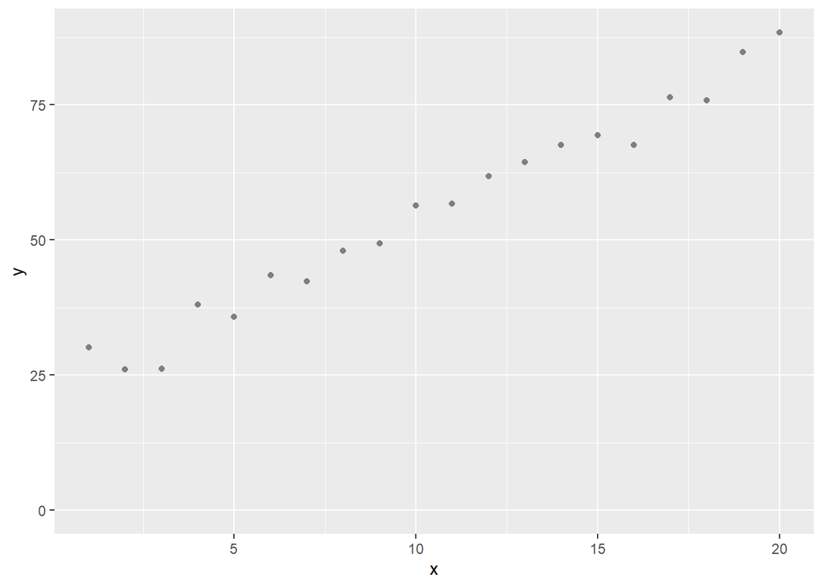

```r
library(tidyverse)
library(ggplot2)

population_b0 <- 20 # intercept
population_b1 <- 3 # slope

dataset <- data.frame(x = 1:20,
                  y = sapply(1:20, function(x) population_b0 + population_b1 * (x + rnorm(n = 1, mean = 1, sd = 1)))
                  )
ggplot(data = dataset, aes(x = x, y = y)) + geom_point(colour = 'grey50') + expand_limits(y = 0)
```

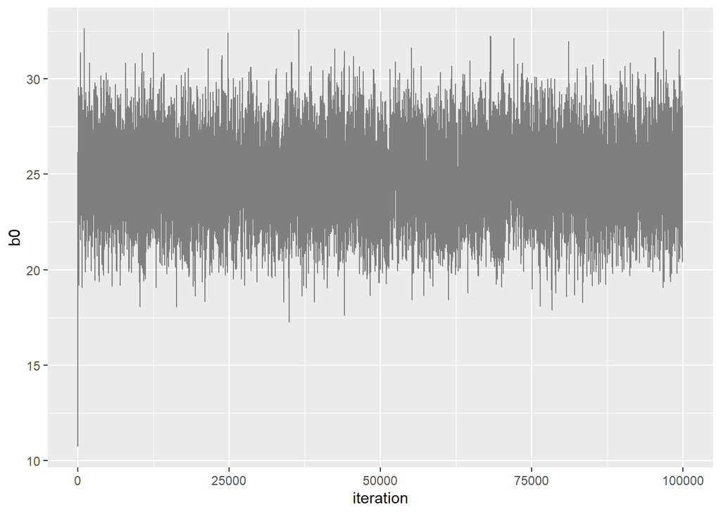

```r
model_pdf <-  function(obs, mu, sigma) exp(-0.5*((obs-mu)/sigma)^2) / (sqrt(sigma^2*2*pi))

posterior_pdf <- function(y, x, b0, b1, sigma, b0_prior, b1_prior, sigma0_prior, sigma1_prior) {
    log( model_pdf(y, b0 + b1 * x, sigma) ) +
    log( model_pdf(b0, b0_prior, sigma0_prior) ) +
    log( model_pdf(b1, b1_prior, sigma1_prior) )
} # conversely to the example above, here we must take the log of the probabilities, otherwise with 3 probability products the results will be most likely always 0

proposed <- function(b, sd) rnorm(n = 1, mean = b, sd = sd)

iterations = 1e5
b0 <- 10 # start of the chain (intercept)
b1 <- 1 # start of the chain (slope)
sigma_proposed_b0 = 2
sigma_proposed_b1 = 0.5

sigma <- 10 # standard deviation of the normal model used for the likelihood probability density function. Also in this case we provide it to the model and we do not estimate it
b0_prior <- 25 # prior belief of the intercept
b1_prior <- 2.5 # prior belief of the slope
sigma0_prior <- 10 # standard deviation of the intercept
sigma1_prior <- 2.5 # standard deviation of the slope

coef_b0 <- rep(NA, iterations)
coef_b1 <- rep(NA, iterations)

for (i in 1:iterations) {
  b0_prime <- proposed(b0, sigma_proposed_b0)
  b1_prime <- proposed(b1, sigma_proposed_b1)

  i_posterior_p <- posterior_pdf(dataset$y, dataset$x, b0_prime, b1_prime, sigma, b0_prior, b1_prior, sigma0_prior, sigma1_prior)
  i_posterior_p <- Reduce(`+`, i_posterior_p)

  previous_posterior_p <- posterior_pdf(dataset$y, dataset$x, b0, b1, sigma, b0_prior, b1_prior, sigma0_prior, sigma1_prior)
  previous_posterior_p <- Reduce(`+`, previous_posterior_p)

  improvement <- exp(i_posterior_p - previous_posterior_p)

  ratio <- min(1, improvement)

  accept <- runif(1) < ratio

  coef_b0[i] <- ifelse(accept, b0_prime, b0)
  coef_b1[i] <- ifelse(accept, b1_prime, b1)

  b0 <- coef_b0[i]
  b1 <- coef_b1[i]
}

results_combined = data.frame(b0 = coef_b0, b1 = coef_b1, improvement = improvement, iteration = 1:iterations)

ggplot(data = results_combined, aes(x = iteration, y = b0)) + geom_line(colour = 'grey50')
```

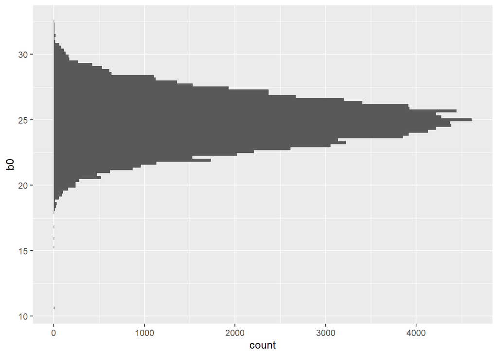

```r
ggplot(data = results_combined, aes(y=b0)) + geom_histogram(bins = 100)
```

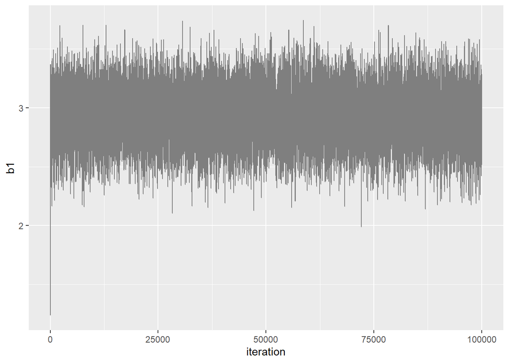

```r
ggplot(data = results_combined, aes(x = iteration, y = b1)) + geom_line(colour = 'grey50')
```

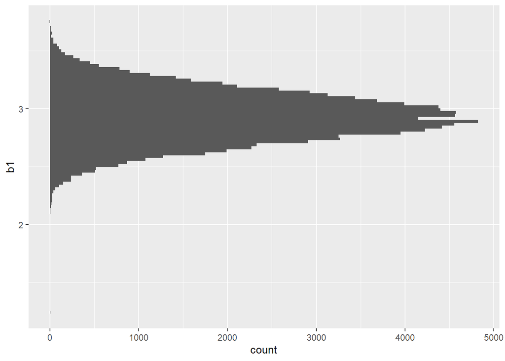

```r
ggplot(data = results_combined, aes(y=b1)) + geom_histogram(bins = 100)
```

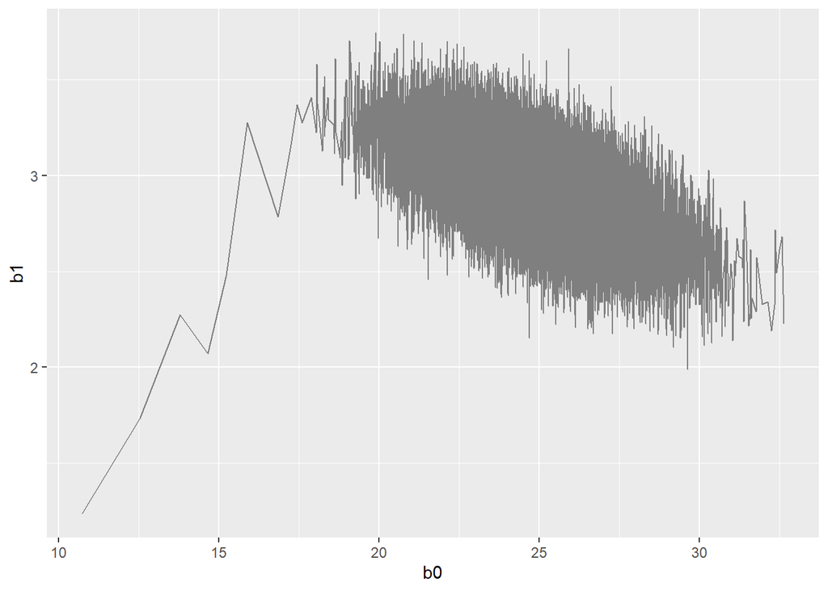

```r
ggplot(data = results_combined, aes(x = b0, y = b1)) + geom_line(colour = 'grey50')
```

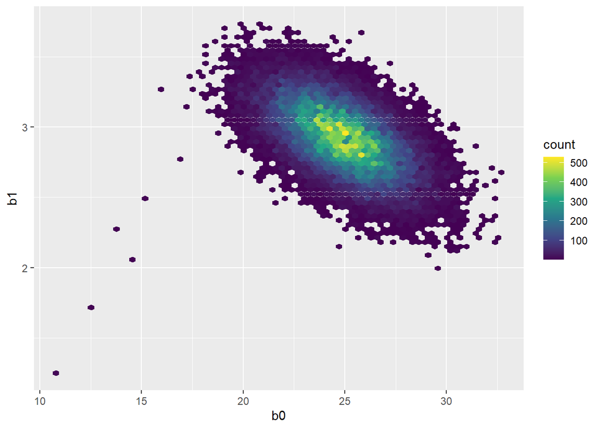

```r
ggplot(data = results_combined, aes(x = b0, y = b1)) + geom_hex(bins = 70) + scale_fill_continuous(type = "viridis")
```

In this example we unrevel one of the most important concepts behind the Metropoin-Hastings algorithm (also visible in the previous example, but enphasized better here), which made it so popular. The algoritm samples more and more densely where the probability is higher which gives us a good estimate of the parameter(s) maxima without wasting computations on regions that are not contributing significantly to the model.  
Finally, let’s fit the full linear model.

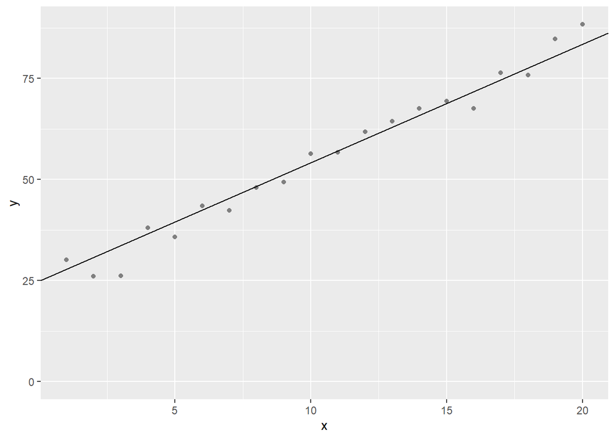

```r
b0 <- median(results_combined$b0)
b1 <- median(results_combined$b1)

ggplot(data = dataset, aes(x = x, y = y)) + geom_point(colour = 'grey50') + geom_abline(intercept = b0, slope = b1) + expand_limits(y = 0)
```

Check the residuals.

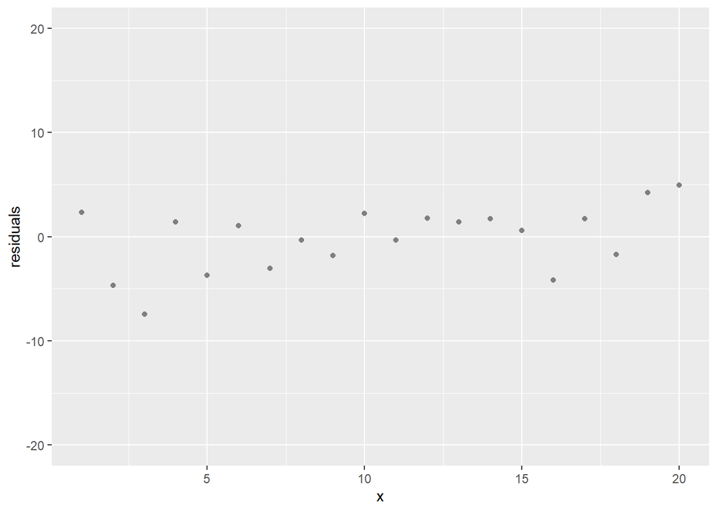

```r
dataset$residuals <- dataset$y - (b0 + b1 * dataset$x)

ggplot(data = dataset, aes(x = x, y = residuals)) + geom_point(colour = 'grey50') + expand_limits(y = c(-20, 20))
```

As shown by the residuals, the model is good although not perfect. The relatively strong prior is slightly ‘forcing’ the parameter’s estimate.

## 3.4 Poisson linear model

In this example we will analyze a situation where the residuals are not modeled by a normal distribution (like in all the previous cases), but rather, by a Poisson distribution. This distribution is characterized by having identical mean and standard deviation. Therefore, larger values will have larger dispersion. This characteristic (mean-variance relationship) is termed heteroschedacity and can be seen in the figure below where higher x values have higher dispersion. Situations such as this one are common for count data.

Cases such as this one; as well as others such as the logistic regression (where the model require an additional link function) are normally fit using GLM approaches rather than OLS. For this particular case, in order to show the above-mentioned heteroschedacity it was necessary to increase the sample size. Because of this, we decided to use the built-in ‘stats::dpois’ function due to the better performance compared to the one explicitly specified pdf function (model_pdf). ‘model_pdf’ here is reported purely for the purpose of documentation.

Last, also in this case (conceptually like in the case above) it would have been possible to introduce in the model the coefficient for the intercept, but we decided to simplify this case for the sake of clarity.

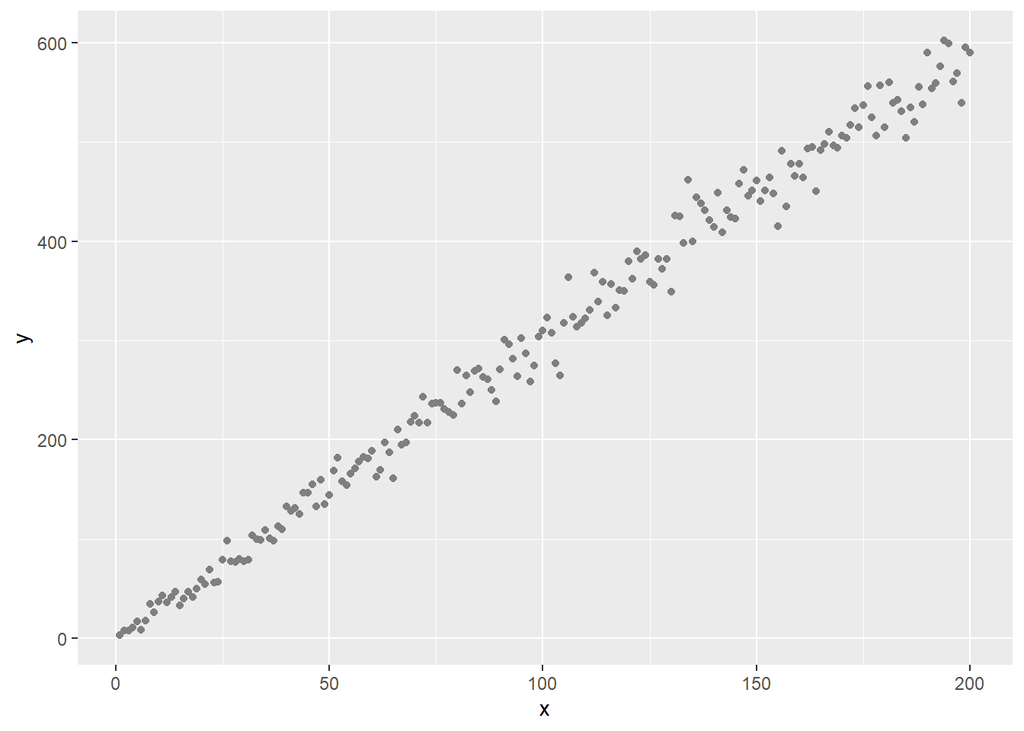

```r
library(tidyverse)
library(ggplot2)


population_b <- 3 # slope

dataset <- data.frame(
  x = 1:200,
  y = sapply(1:200, function(x) rpois(n = 1, lambda = population_b * x))
  )

ggplot(data = dataset, aes(x = x, y = y)) + geom_point(colour = 'grey50')
```

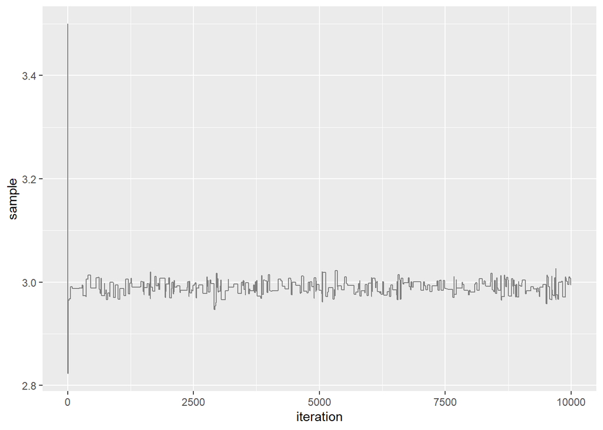

```r
model_pdf <- function(obs, lambda) (lambda^obs * exp(-lambda)) / factorial(obs)
prior_pdf <- function(obs, mu, sigma) exp(-0.5*((obs-mu)/sigma)^2) / (sqrt(sigma^2*2*pi)) # As mentioned before, this is just our prior belief on the coefficient. There is no relationship whatsoever binding this distribution with the one of the likelihood. It can be anything, even an uniform distribution.


posterior_pdf <- function(y, x, b, b_prior, sigma_prior) {
  log( dpois(y, b * x) ) +
  log( prior_pdf(b, b_prior, sigma_prior) )
  # if one wanted a completely uninformative prior such as an uniform distribution, the line above can be replaced with:
  # log( 1 )
}

proposed <- function(b, sd) rnorm(n = 1, mean = b, sd = sd)

iterations = 1e4
b <- 3.5 # start of the chain

b_prior <- 2.7 # prior belief of the parameter
sigma_prior <- 2 # prior belief of the standard deviation of the parameter
sigma_proposed <- 0.5
stored <- rep(NA, iterations)



for (i in 1:iterations) {
  b_prime <- proposed(b, sigma_proposed)

  i_posterior_p <- posterior_pdf(dataset$y, dataset$x, b_prime, b_prior, sigma_prior)
  i_posterior_p <- Reduce(`+`, i_posterior_p)

  previous_posterior_p <- posterior_pdf(dataset$y, dataset$x, b, b_prior, sigma_prior)
  previous_posterior_p <- Reduce(`+`, previous_posterior_p)

  improvement <- exp(i_posterior_p - previous_posterior_p)

  ratio <- min(1, improvement)
  accept <- runif(1) < ratio
  stored[i] <- ifelse(accept, b_prime, b)
  b <- stored[i]
}

results_combined = data.frame(sample = stored, improvement = improvement, iteration = 1:iterations)

ggplot(data = results_combined, aes(x = iteration, y = sample)) + geom_line(colour = 'grey50')
```

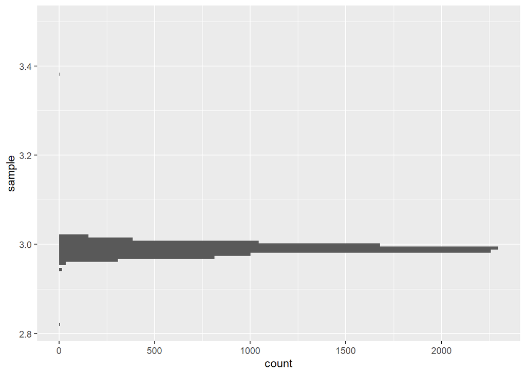

```r
ggplot(data = results_combined, aes(y=sample)) + geom_histogram(bins = 100)
```

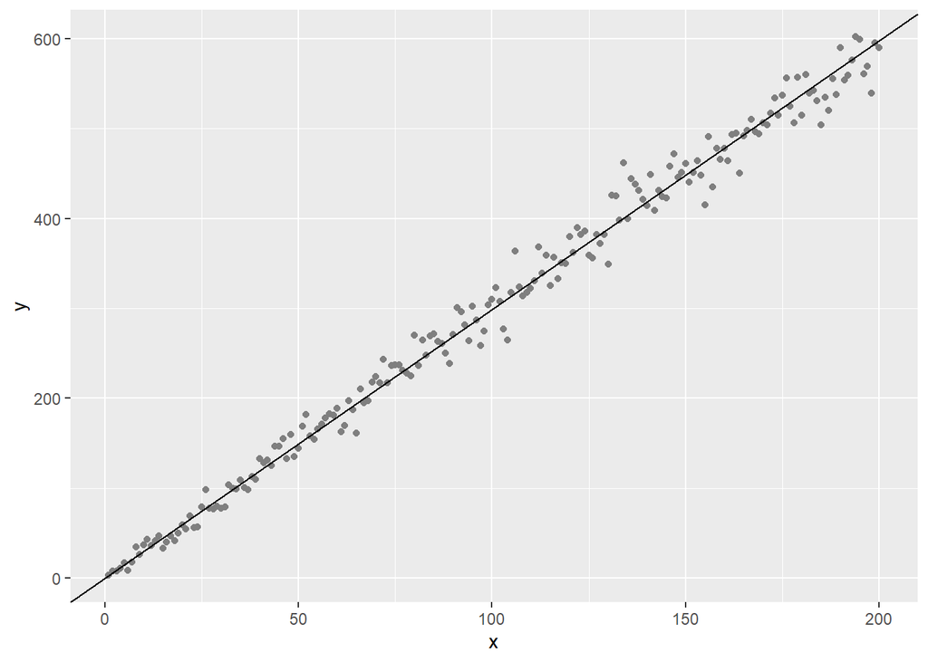

```r
b <- median(results_combined$sample)
ggplot(data = dataset, aes(x = x, y = y)) + geom_point(colour = 'grey50') + geom_abline(intercept = 0, slope = b)
```

Heteroschedasticity in the residuals

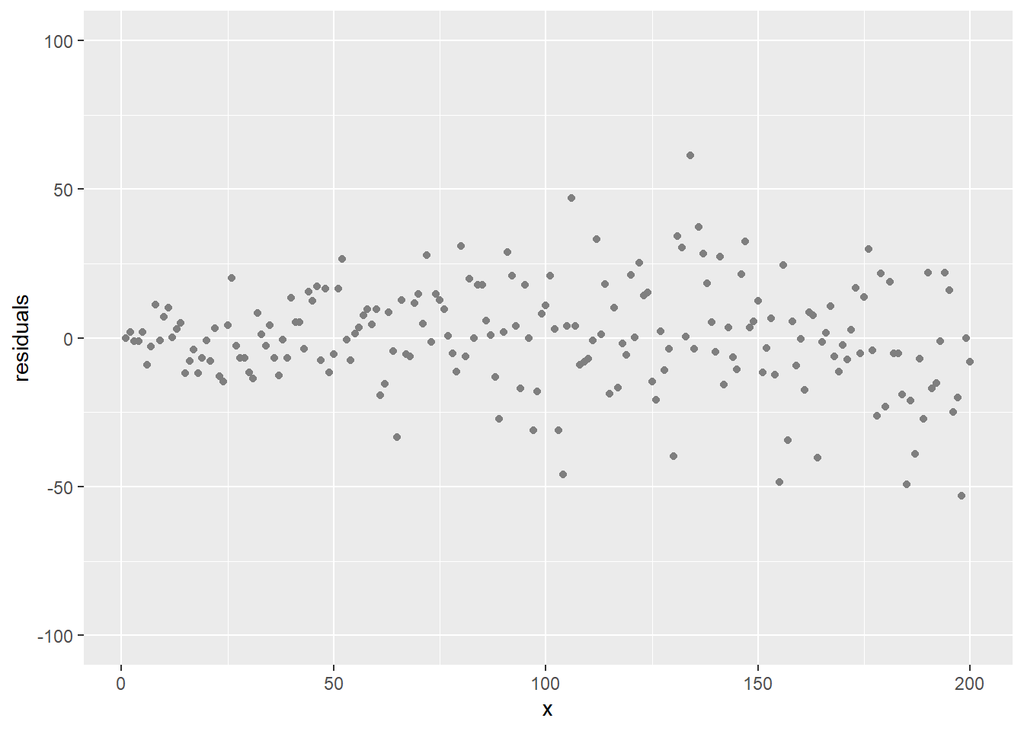

```r
dataset$residuals <- dataset$y - (b * dataset$x)
ggplot(data = dataset, aes(x = x, y = residuals)) + geom_point(colour = 'grey50') + expand_limits(y = c(-100, 100))
```

# 4 Appendix: Potential advantages of the bayesian approach over the frequentist one

## 4.1 Bimodal normal distributions example

In this example we will introduce a situation where a Bayesian approach might have some advantages over maximum likelihood. In this example we will map the probability density function of a more complex distribution, namely one containing 2 normal distributions.

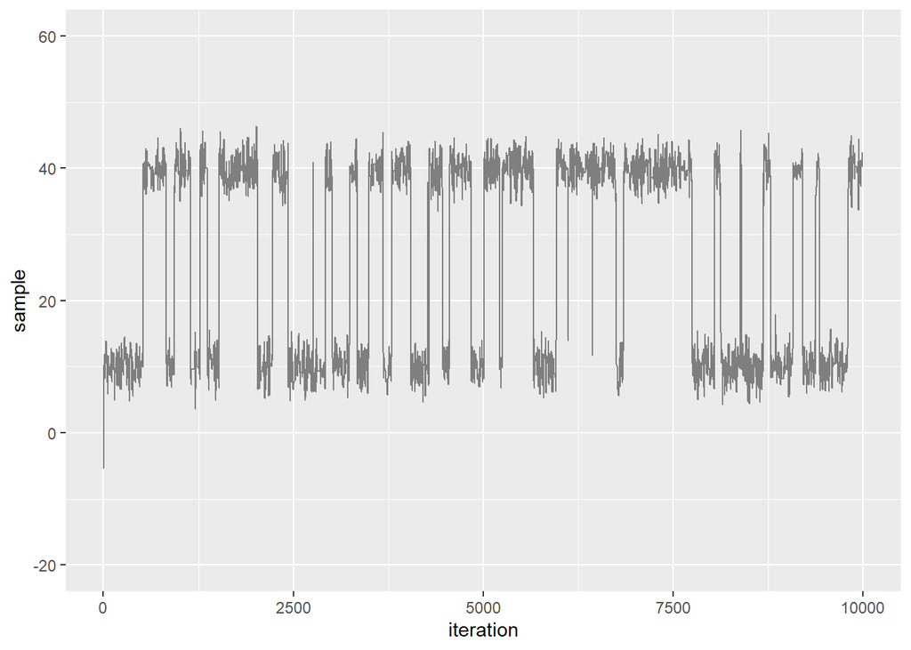

```r
library(tidyverse)
library(ggplot2)


model_pdf <- function(x, sigma) {
  exp(-0.5*((x-mu1)/sigma)^2) / (sigma*sqrt(2*sigma*pi)) +
  exp(-0.5*((x-mu2)/sigma)^2) / (sigma*sqrt(2*sigma*pi))
}

proposed <- function(x, sd) rnorm(n = 1, mean = x, sd = sd)

iterations = 1e4 # number of iterations
x <- -20 # starting value of the chain
sigma = 2
sigma_proposed = 10
mu1 = 10
mu2 = 40
stored <- rep(NA, iterations)
improvement <- rep(NA, iterations)


for (i in 1:iterations) {
  x_i <- proposed(x, sigma_proposed)
  improvement[i] <- model_pdf(x_i, sigma) / model_pdf(x,  sigma)
  ratio <- min(1, improvement[i])
  accept <- runif(1) < ratio
  stored[i] <- ifelse(accept, x_i, x)
  x <- stored[i]
}

results_combined = data.frame(sample = stored, improvement = improvement, iteration = 1:iterations)

ggplot(data = results_combined, aes(x = iteration, y = sample)) + geom_line(colour = 'grey50') + expand_limits(y = c(-20, 60))
```

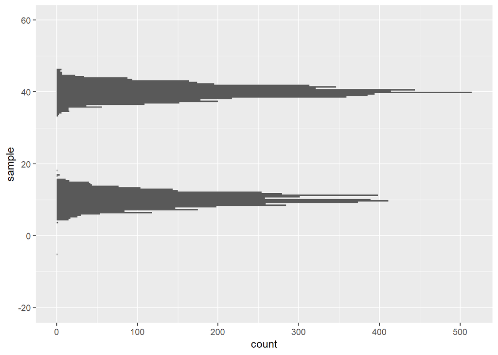

```r
ggplot(data = results_combined, aes(y=sample)) + geom_histogram(bins = 200) + expand_limits(y = c(-20, 60))
```

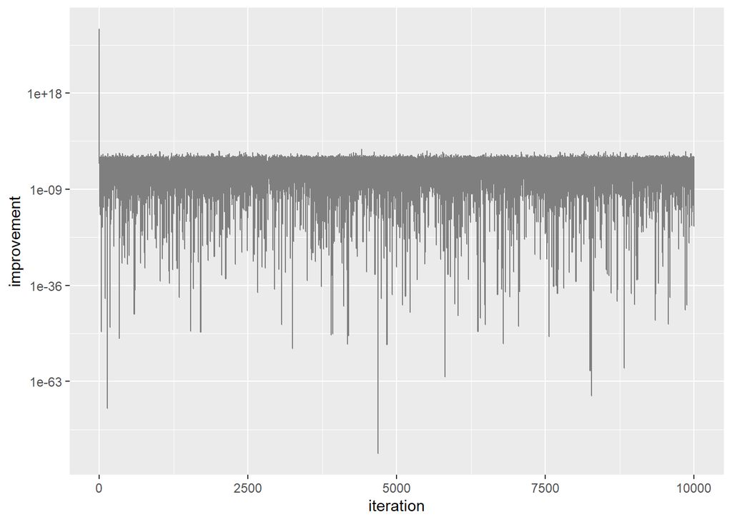

```r
ggplot(data = results_combined, aes(x = iteration, y = improvement)) + geom_line(colour = 'grey50') + scale_y_log10()
```

An important consideration regarding situations like the one in this example, is that often MCMC algorithms do not manage to sample both distributions (may get stuck on 1 of the 2). This can happen for example if we used a lower sigma_proposed, in that case, what happens is that if the random steps are not large enough to “jump” on high probability regions on the other distributions, the algorith remains stuck on just 1 distribution. Let’s run the same example above but with sigma_proposed of 3 instead of 10.

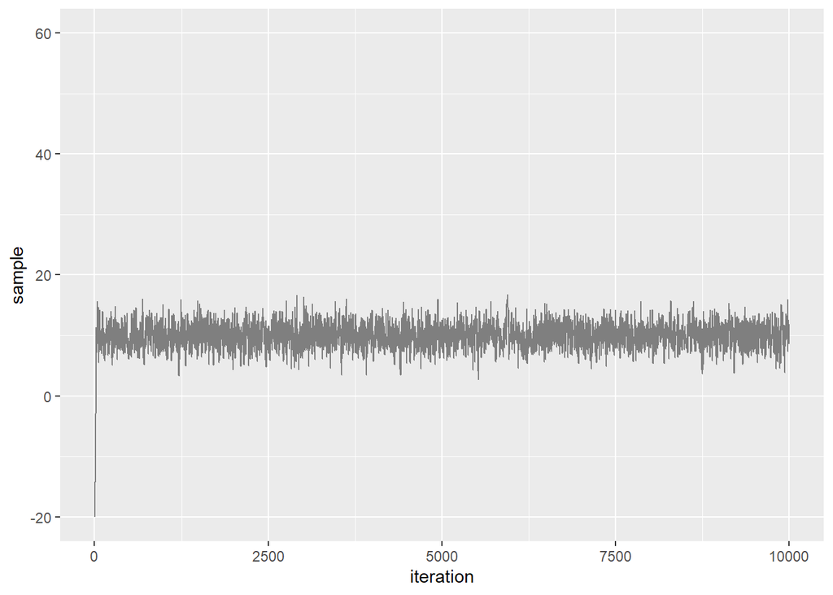

Note that starting the chain from -20 allow us to sample only from the mu1 distribution (mean = 10) and we completely miss the mu2 distribution (mean = 40).  
The way this problem was solved in the implementation above was simply to inflate the sigma_proposed parameter to allow the sampler to perform bigger jumps.  
Normally, more sophisticated MCMC algorithms (compared to the very simple one shown here) use a different strategy to solve this problem, namely, run different MCMC chains starting from different values and then combine the results.  
Let’s try to run the example above starting the chain from 60 instead of -20. In this case we sample uniquely from the mu2 distribution (mean = 40).

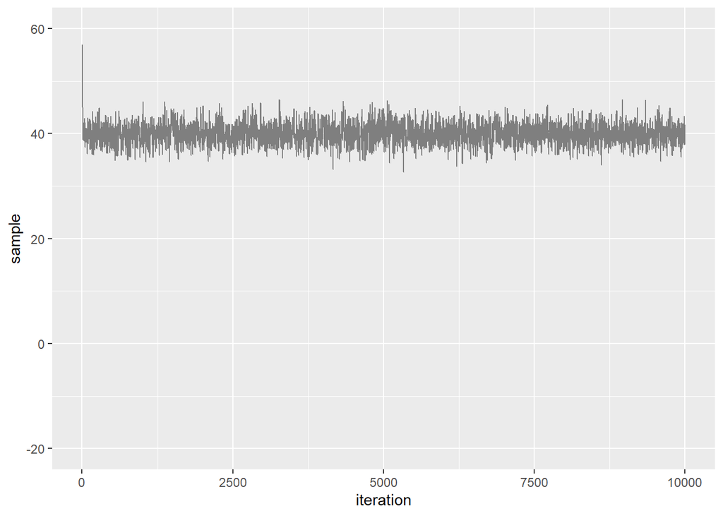

## 4.2 Hypothesis testing

Before we mentioned that a bayesian approach might be more accurate than a frequentist one in cases such the one where we have a multi-modal probability density function. There is an another scenario where the frequentist approach would be misleading. The frequentist approach tend to be sensitive to the H0 (null hypothesis): it can happen that a population’s parameter is truly different from the H0 value, however, whenever the sample size is low, or the standard deviation is high, we might fail to reject H0.  
Let’s take a look to the example below. Let’s suppose that we are asked to bet if the sample ‘X’ has mean 9 or 10. With a frequentist approach we would use 1 of the 2 values (let’s say 9) as H0 and test if the mean differs from it (here for the purpose of the example we know it does since we specify $\mu = 10$ when the random variable ‘X’ is generated). In this case, the p-value is 0.07, if we use a cutoff of 0.05 we would fail to reject H0 and therefore we would bet on the mean of the random variable to be 9.

```r
set.seed(1)
X <- rnorm(n = 7, mean = 10, sd = 1.5) # Our sample from the population (normal population with mean 10 and standard deviation 4)
X
```

```
## [1]  9.060319 10.275465  8.746557 12.392921 10.494262  8.769297 10.731144
```

```r
t.test(x = X, mu = 9)
```

```
##
##  One Sample t-test
##
## data:  X
## t = 2.1324, df = 6, p-value = 0.07695
## alternative hypothesis: true mean is not equal to 9
## 95 percent confidence interval:
##   8.842633 11.291643
## sample estimates:
## mean of x
##  10.06714
```

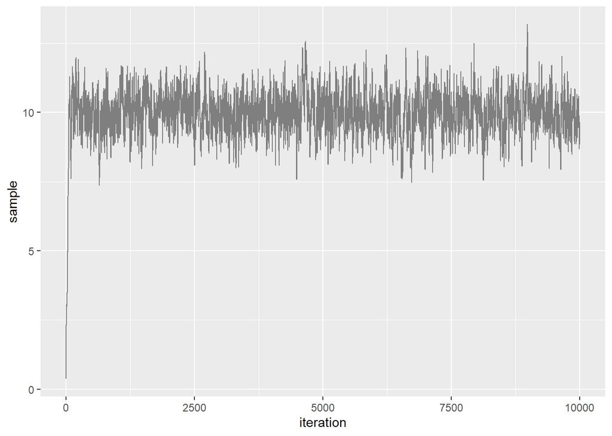

```r
library(tidyverse)
library(ggplot2)

model_pdf <-  function(obs, mu, sigma) exp(-0.5*((obs-mu)/sigma)^2) / (sqrt(sigma^2*2*pi))

posterior_pdf <- function(x, mu, sigma, mu_prior, sigma_prior) model_pdf(x, mu, sigma) * model_pdf(mu, mu_prior, sigma_prior) # likelihood * prior

proposed <- function(mu, sd) rnorm(n = 1, mean = mu, sd = sd)

iterations = 1e4
mu <- 0 # start of the chain (slope)
sigma_proposed = 0.5

sigma <- 2
mu_prior <- 9.5 # we pick an uninformative (unbiased) prior, which is exactly in the middle of the 2 values of interest
sigma_prior <- 10
stored <- rep(NA, iterations)


for (i in 1:iterations) {
  mu_prime <- proposed(mu, sigma_proposed)

  i_posterior_p <- posterior_pdf(X, mu_prime, sigma, mu_prior, sigma_prior)
  i_posterior_p <- Reduce(`*`, i_posterior_p)

  previous_posterior_p <- posterior_pdf(X, mu, sigma, mu_prior, sigma_prior)
  previous_posterior_p <- Reduce(`*`, previous_posterior_p)

  improvement <- i_posterior_p / previous_posterior_p

  ratio <- min(1, improvement)
  accept <- runif(1) < ratio
  stored[i] <- ifelse(accept, mu_prime, mu)
  mu <- stored[i]
}

results_combined = data.frame(sample = stored, improvement = improvement, iteration = 1:iterations)

ggplot(data = results_combined, aes(x = iteration, y = sample)) + geom_line(colour = 'grey50')
```

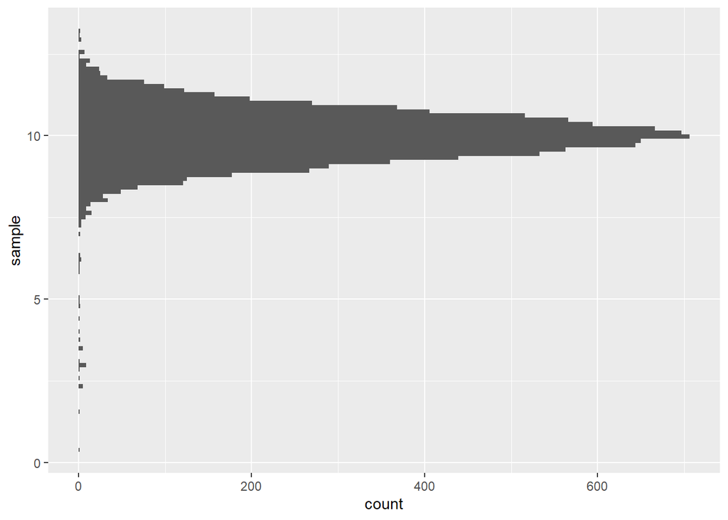

```r
ggplot(data = results_combined, aes(y=sample)) + geom_histogram(bins = 100)
```

```r
median(results_combined$sample)
```

```
## [1] 10.00446
```

Estimate of mu using the bayesian approach would make us choose correctly: $\mu = 10$. This happens for the reason explained above, the frequentist approach is very sensitive to the H0 and needs solid evidences in order to reject it.

# 5 Bayesian statistics in R

Packages: rstan, BAS (recmmended)  
Additional: atmcmc, BRugs, mcmc, MCMCpack, ramcmc.